# Checks for the final model

**NoteNote**

This is a template that can be used to systematically inspect the Bayesian Modeling process, mainly inspired on the WAMBS checklist (see Depaoli (2020) for a tutorial). Based on this report it is an option to create a supplementary document for the analyses presented in the actual paper.

# 1. Before estimating the model

## 1.1 Do you understand the priors?

### 1.1.1 Preparation

We will visualize the priors and we will run “prior predictive checks”. Therefore we need to load the dataset and a number of packages. This is done in the following code block.

**Note**

This template uses the same running example as the workshop: commuting times. The dependent variable is `CommuteTime`, the one-way commute in minutes, and we want to know whether it is affected by how far someone lives from work (`Distance_c`, in kilometres, centred on the mean distance) and by what time they leave in the morning (`Departure_c`, in hours after 07:00). Both predictors are centred, so the intercept is the expected commute for someone living the average distance away who leaves at 07:00.

```r
library(here)       # to easily access files
library(tidyverse)  # for all data wrangling and plotting
library(brms)       # to have functions to run and check models
library(ggmcmc)     # to generate some information on our model
library(bayesplot)  # to use certain plotting functions
library(patchwork)  # to combine multiple ggplots into one plot
library(priorsense) # to perform prior sensibility analyses

load(
  here(
    "Presentations",
    "CommuteData.RData")
  )

CommuteTimes_Mod2 <- readRDS(
  here(
    "Presentations",
    "Output",
    "CommuteTimes_Mod2.RDS"
  )
)
```

These are the different packages used in this template: (Müller 2020; Wickham et al. 2019; Bürkner 2017; Fernández-i-Marín 2016; Gabry and Mahr 2022; Pedersen 2022; Kallioinen et al. 2021)

### 1.1.2 Specification of the priors

The model was formulated as:

$$\begin{aligned}
& \text{CommuteTime}_i \sim N(\mu,\sigma_e)\\
& \mu = \beta_0 + \beta_1*\text{Distance\_c}_i + \beta_2*\text{Departure\_c}_i + e_i
\end{aligned}$$

To get an overview of the different parameters for which a prior has to be defined, we can use the `get_prior( )` function and specify our model. This will result in an overview of the default priors set by the `brms` package.

```r
get_prior(
  CommuteTime ~ 1 + Distance_c + Departure_c,
  data = CommuteData
)
```

```
                    prior     class        coef group resp dpar nlpar lb ub
                   (flat)         b
                   (flat)         b Departure_c
                   (flat)         b  Distance_c
 student_t(3, 26.5, 12.4) Intercept
    student_t(3, 0, 12.4)     sigma                                    0
       source
      default
 (vectorized)
 (vectorized)
      default
      default
```

In the following table we made a list of all the priors that were defaulted by `brms`.

Table 1. Overview of the default priors used in the example model

[output not shown]

We could also define our own priors. The next table gives an overview of our own weakly informative priors, where we mainly defined custom priors for the effects of our two independent variables.

In the following table we made a list of potential custom priors.

Table 2. Overview of the custom priors used in the example model

[output not shown]

### 1.1.3 Visualisation of the priors

To make some of the priors more tangible we plot the prior distributions in this part. We can make use of different functions from `base` but we will also rely on the `metRology` package for visualizing the student t distributions. Flat priors (for the effect of both independent variables) don’t need to be plotted, as they imply that all values get a similar probability.

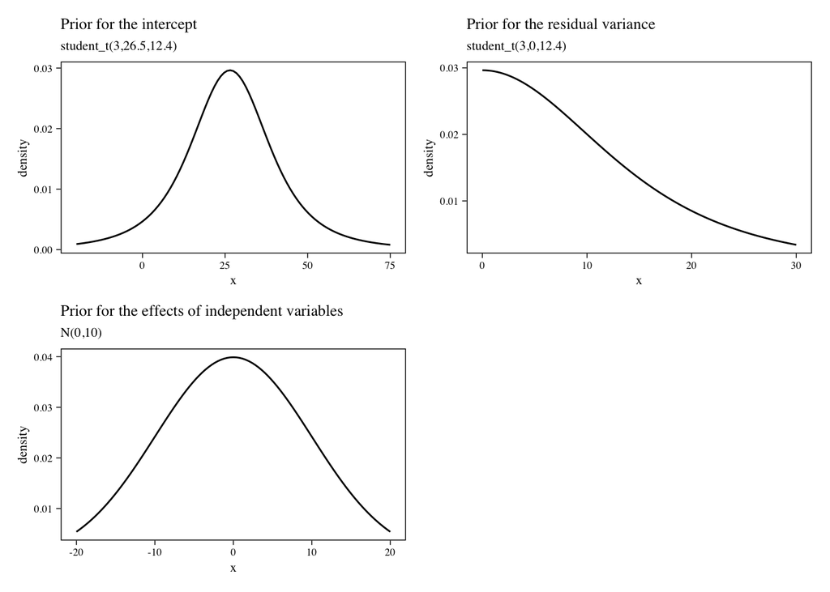

Probability density plots for the different priors used in the example model

To use these priors for our model, we use the `set_prior( )` function in `bmrs`. We only have to define the priors that we want to change. The resulting object (`Custom_priors`) can be used in the model definition.

```r
Custom_priors <-
  c(
    set_prior(
      "normal(0,10)",
      class = "b",
      coef = "Distance_c"),
    set_prior(
      "normal(0,10)",
      class = "b",
      coef = "Departure_c")
    )
```

### 1.1.4 Check the predictions based on the priors

To check the predictions based on the priors (aka prior predictive checks) we “estimate the model” based on the priors only. This equals to generating the default number of chains and iterations of potential parameter values, given the prior probabilities defined and not taking into account the data. The results can be stored in an object.

```r
Fit_Model_priors <-
  brm(
    CommuteTime ~ 1 + Distance_c + Departure_c,
    data = CommuteData,
    prior = Custom_priors,
    backend = "cmdstanr",
    cores = 4,
    sample_prior = "only"
    )
```

```
Running MCMC with 4 parallel chains...

Chain 1 Iteration:    1 / 2000 [  0%]  (Warmup)
Chain 1 Iteration:  100 / 2000 [  5%]  (Warmup)
Chain 1 Iteration:  200 / 2000 [ 10%]  (Warmup)
Chain 1 Iteration:  300 / 2000 [ 15%]  (Warmup)
Chain 1 Iteration:  400 / 2000 [ 20%]  (Warmup)
Chain 1 Iteration:  500 / 2000 [ 25%]  (Warmup)
Chain 1 Iteration:  600 / 2000 [ 30%]  (Warmup)
Chain 1 Iteration:  700 / 2000 [ 35%]  (Warmup)
Chain 1 Iteration:  800 / 2000 [ 40%]  (Warmup)
Chain 1 Iteration:  900 / 2000 [ 45%]  (Warmup)
Chain 1 Iteration: 1000 / 2000 [ 50%]  (Warmup)
Chain 1 Iteration: 1001 / 2000 [ 50%]  (Sampling)
Chain 1 Iteration: 1100 / 2000 [ 55%]  (Sampling)
Chain 1 Iteration: 1200 / 2000 [ 60%]  (Sampling)
Chain 1 Iteration: 1300 / 2000 [ 65%]  (Sampling)
Chain 1 Iteration: 1400 / 2000 [ 70%]  (Sampling)
Chain 1 Iteration: 1500 / 2000 [ 75%]  (Sampling)
Chain 1 Iteration: 1600 / 2000 [ 80%]  (Sampling)
Chain 1 Iteration: 1700 / 2000 [ 85%]  (Sampling)
Chain 1 Iteration: 1800 / 2000 [ 90%]  (Sampling)
Chain 1 Iteration: 1900 / 2000 [ 95%]  (Sampling)
Chain 1 Iteration: 2000 / 2000 [100%]  (Sampling)
Chain 2 Iteration:    1 / 2000 [  0%]  (Warmup)
Chain 2 Iteration:  100 / 2000 [  5%]  (Warmup)
Chain 2 Iteration:  200 / 2000 [ 10%]  (Warmup)
Chain 2 Iteration:  300 / 2000 [ 15%]  (Warmup)
Chain 2 Iteration:  400 / 2000 [ 20%]  (Warmup)
Chain 2 Iteration:  500 / 2000 [ 25%]  (Warmup)
Chain 2 Iteration:  600 / 2000 [ 30%]  (Warmup)
Chain 2 Iteration:  700 / 2000 [ 35%]  (Warmup)
Chain 2 Iteration:  800 / 2000 [ 40%]  (Warmup)
Chain 2 Iteration:  900 / 2000 [ 45%]  (Warmup)
Chain 2 Iteration: 1000 / 2000 [ 50%]  (Warmup)
Chain 2 Iteration: 1001 / 2000 [ 50%]  (Sampling)
Chain 2 Iteration: 1100 / 2000 [ 55%]  (Sampling)
Chain 2 Iteration: 1200 / 2000 [ 60%]  (Sampling)
Chain 2 Iteration: 1300 / 2000 [ 65%]  (Sampling)
Chain 2 Iteration: 1400 / 2000 [ 70%]  (Sampling)
```

[output cut: 43 more lines]

```
Chain 4 Iteration: 1400 / 2000 [ 70%]  (Sampling)
Chain 4 Iteration: 1500 / 2000 [ 75%]  (Sampling)
Chain 4 Iteration: 1600 / 2000 [ 80%]  (Sampling)
Chain 4 Iteration: 1700 / 2000 [ 85%]  (Sampling)
Chain 4 Iteration: 1800 / 2000 [ 90%]  (Sampling)
Chain 4 Iteration: 1900 / 2000 [ 95%]  (Sampling)
Chain 4 Iteration: 2000 / 2000 [100%]  (Sampling)
Chain 1 finished in 0.0 seconds.
Chain 2 finished in 0.0 seconds.
Chain 3 finished in 0.0 seconds.
Chain 4 finished in 0.0 seconds.

All 4 chains finished successfully.
Mean chain execution time: 0.0 seconds.
Total execution time: 0.2 seconds.
```

Next, we can check the implications of these priors by using the `pp_check( )` function. This function simulates data based on `ndraws` number of draws of probable parameter values from our prior probability distribution. So, in the following code 300 new datasets are simulate, each based on another set of potential parameter values. Then this same function also plots the distribution of each of these 300 datasets (light blue lines) over-layed by the distribution of the real observed data (dark blue lines). We can see that some of the simulated datasets show very different distributions compared to the actual dataset.

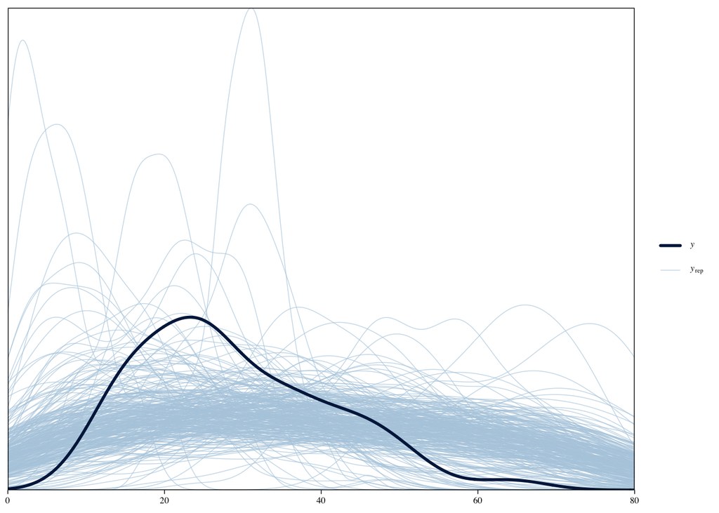

```r
set.seed(1975)
pp_check(
  Fit_Model_priors,
  ndraws = 300) +
  scale_x_continuous(
    limits = c(0,80)
  )
```

We can also generate other types of plots to see whether our priors result in impossible data. For instance, we can compare some summary statistics based on our dataset to how the same summary statistics are distributed for all the simulated datasets. First let’s apply this to the median of our data, by including the argument `type = "stat"` and then define the `stat = "median"`.

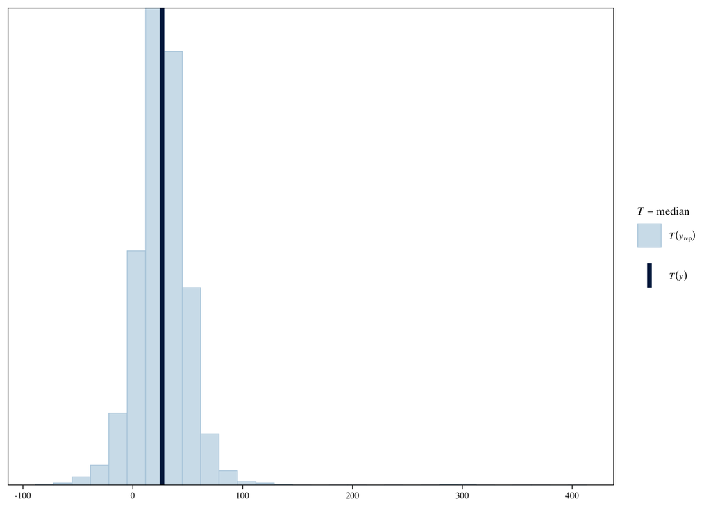

```r
pp_check(Fit_Model_priors,
         type = "stat",
         stat = "median")
```

As we can see in the above graph, some of the simulated datasets based on our priors result in a negative median commuting time, which is of course impossible! We could reconsider our priors here. If we think more carefully about our prior distribution for the effect of `Distance_c` we are still giving quite some probability to very strong effects (e.g., 10 minutes extra for every extra kilometre). The distances in this dataset span about 42 km, so an effect of that size implies predicted commutes swinging by more than 400 minutes, while the commutes we actually observe run from about 10 to 65 minutes. The same holds for the other side of the coin: we give just as much probability to the commute getting 400 minutes *shorter* for people living further away. Clearly our prior is too weakly defined here. Alternatively we could also argue that our model doesn’t really make sense (is there really a linear effect of these variables?). Let’s introduce a more restrictive prior for the beta of `Distance_c` (a normal distribution with a sd = 2) and do a similar check.

```r
Custom_priors2 <-
  c(
    set_prior(
      "normal(0,2)",
      class = "b",
      coef = "Distance_c"),
    set_prior(
      "normal(0,10)",
      class = "b",
      coef = "Departure_c")
    )

Fit_Model_priors2 <-
  brm(
    CommuteTime ~ 1 + Distance_c + Departure_c,
    data = CommuteData,
    prior = Custom_priors2,
    backend = "cmdstanr",
    cores = 4,
    sample_prior = "only"
    )
```

```
Running MCMC with 4 parallel chains...

Chain 1 Iteration:    1 / 2000 [  0%]  (Warmup)
Chain 1 Iteration:  100 / 2000 [  5%]  (Warmup)
Chain 1 Iteration:  200 / 2000 [ 10%]  (Warmup)
Chain 1 Iteration:  300 / 2000 [ 15%]  (Warmup)
Chain 1 Iteration:  400 / 2000 [ 20%]  (Warmup)
Chain 1 Iteration:  500 / 2000 [ 25%]  (Warmup)
Chain 1 Iteration:  600 / 2000 [ 30%]  (Warmup)
Chain 1 Iteration:  700 / 2000 [ 35%]  (Warmup)
Chain 1 Iteration:  800 / 2000 [ 40%]  (Warmup)
Chain 1 Iteration:  900 / 2000 [ 45%]  (Warmup)
Chain 1 Iteration: 1000 / 2000 [ 50%]  (Warmup)
Chain 1 Iteration: 1001 / 2000 [ 50%]  (Sampling)
Chain 1 Iteration: 1100 / 2000 [ 55%]  (Sampling)
Chain 1 Iteration: 1200 / 2000 [ 60%]  (Sampling)
Chain 1 Iteration: 1300 / 2000 [ 65%]  (Sampling)
Chain 1 Iteration: 1400 / 2000 [ 70%]  (Sampling)
Chain 1 Iteration: 1500 / 2000 [ 75%]  (Sampling)
Chain 1 Iteration: 1600 / 2000 [ 80%]  (Sampling)
Chain 1 Iteration: 1700 / 2000 [ 85%]  (Sampling)
Chain 1 Iteration: 1800 / 2000 [ 90%]  (Sampling)
Chain 1 Iteration: 1900 / 2000 [ 95%]  (Sampling)
Chain 1 Iteration: 2000 / 2000 [100%]  (Sampling)
Chain 2 Iteration:    1 / 2000 [  0%]  (Warmup)
Chain 2 Iteration:  100 / 2000 [  5%]  (Warmup)
Chain 2 Iteration:  200 / 2000 [ 10%]  (Warmup)
Chain 2 Iteration:  300 / 2000 [ 15%]  (Warmup)
Chain 2 Iteration:  400 / 2000 [ 20%]  (Warmup)
Chain 2 Iteration:  500 / 2000 [ 25%]  (Warmup)
Chain 2 Iteration:  600 / 2000 [ 30%]  (Warmup)
Chain 2 Iteration:  700 / 2000 [ 35%]  (Warmup)
Chain 2 Iteration:  800 / 2000 [ 40%]  (Warmup)
Chain 2 Iteration:  900 / 2000 [ 45%]  (Warmup)
Chain 2 Iteration: 1000 / 2000 [ 50%]  (Warmup)
Chain 2 Iteration: 1001 / 2000 [ 50%]  (Sampling)
Chain 2 Iteration: 1100 / 2000 [ 55%]  (Sampling)
Chain 2 Iteration: 1200 / 2000 [ 60%]  (Sampling)
Chain 2 Iteration: 1300 / 2000 [ 65%]  (Sampling)
Chain 2 Iteration: 1400 / 2000 [ 70%]  (Sampling)
```

[output cut: 43 more lines]

```
Chain 4 Iteration: 1400 / 2000 [ 70%]  (Sampling)
Chain 4 Iteration: 1500 / 2000 [ 75%]  (Sampling)
Chain 4 Iteration: 1600 / 2000 [ 80%]  (Sampling)
Chain 4 Iteration: 1700 / 2000 [ 85%]  (Sampling)
Chain 4 Iteration: 1800 / 2000 [ 90%]  (Sampling)
Chain 4 Iteration: 1900 / 2000 [ 95%]  (Sampling)
Chain 4 Iteration: 2000 / 2000 [100%]  (Sampling)
Chain 1 finished in 0.0 seconds.
Chain 2 finished in 0.0 seconds.
Chain 3 finished in 0.0 seconds.
Chain 4 finished in 0.0 seconds.

All 4 chains finished successfully.
Mean chain execution time: 0.0 seconds.
Total execution time: 0.2 seconds.
```

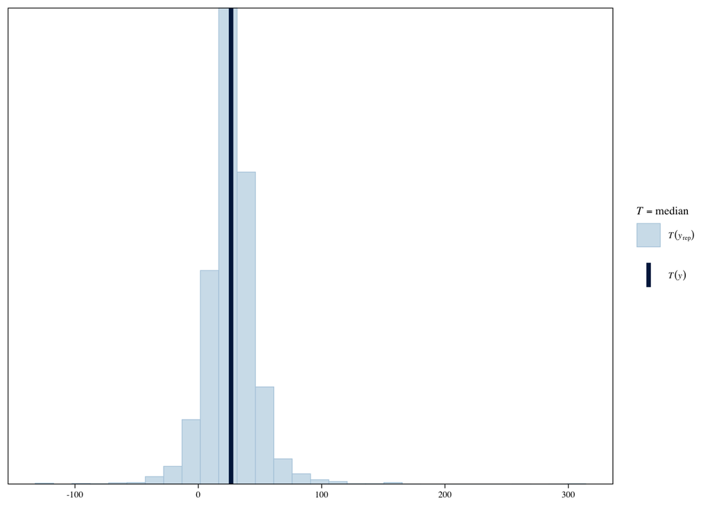

```r
pp_check(Fit_Model_priors2,
         type = "stat",
         stat = "median")
```

This looks better! Now less of the simulated datasets is resulting in a negative median commuting time. Given that we have a large dataset it is not such a big problem (let’s see later what the impact of the chosen prior is).

# 2. After estimation before inspecting results

## 2.1 Check convergence?

Important in the Bayesian workflow is to control whether the MCMC algorithm converged well and that all parameters are estimated properly. Different complementary methods can be used to inspect proper convergence of the MCMC algorithm.

**Note**

In what follows we will work with the model estimated with the default `brms` priors. So we didn’t re-run the model with our custom priors. Of course, in your project you should do this first and then do the later checks!

### 2.1.1 Does the trace-plot exhibit convergence?

Below we plot the different trace-plots (aka caterpillar plots) for the parameters estimated. As can be seen from these plots no strange patterns occur. All the chains mix well, meaning that we can conclude that the model converged.

**Note**

To create the caterpillar plots we made use of the `ggs( )` function from the package `ggmcmc`. Then we make use of the information on the `Parameter`column in the resulting object to create a plot making use of `ggplot2`.

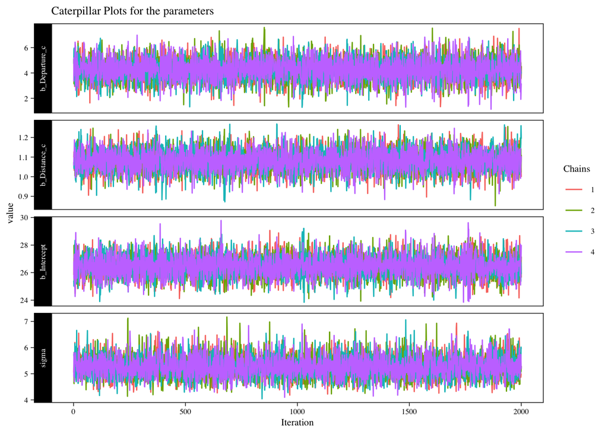

Caterpillar plots for fixed part of the model

```r
Model_chains <- ggs(CommuteTimes_Mod2)

Model_chains %>%
  filter(Parameter %in% c(
          "b_Intercept",
          "b_Distance_c",
          "b_Departure_c",
          "sigma"
          )
  ) %>%
  ggplot(aes(
    x   = Iteration,
    y   = value,
    col = as.factor(Chain)))+
  geom_line() +
  facet_grid(Parameter ~ .,
             scale  = 'free_y',
             switch = 'y') +
  labs(title = "Caterpillar Plots for the parameters",
       col   = "Chains")
```

### 2.1.2 R-hat statistic

Next we can have a look at both the $\widehat{R}$ values as well as the *Effective Sample Sizes* (ESS) for each parameter in the model. Following the rules of thumb in Vehtari et al. (2021) we consider that $\widehat{R}$ <1.015 and ESS > 400 to rely on the $\widehat{R}$ as indicators of convergence of the MCMC sampling. Printing the summary of our model gives us the necessary information:

```r
summary(CommuteTimes_Mod2)
```

```
 Family: gaussian
  Links: mu = identity; sigma = identity
Formula: CommuteTime ~ 1 + Distance_c + Departure_c
   Data: CommuteData (Number of observations: 90)
  Draws: 4 chains, each with iter = 4000; warmup = 2000; thin = 1;
         total post-warmup draws = 8000

Regression Coefficients:
            Estimate Est.Error l-95% CI u-95% CI Rhat Bulk_ESS Tail_ESS
Intercept      26.47      0.78    24.97    28.03 1.00     9014     6016
Distance_c      1.08      0.06     0.97     1.19 1.00     9079     6488
Departure_c     4.27      0.88     2.55     6.00 1.00     8852     5919

Further Distributional Parameters:
      Estimate Est.Error l-95% CI u-95% CI Rhat Bulk_ESS Tail_ESS
sigma     5.26      0.41     4.52     6.14 1.00     7701     5960

Draws were sampled using sample(hmc). For each parameter, Bulk_ESS
and Tail_ESS are effective sample size measures, and Rhat is the potential
scale reduction factor on split chains (at convergence, Rhat = 1).
```

Across the parameters in that table the largest $\widehat{R}$ is 1.0009 and the smallest bulk ESS is 7701. Read those against the thresholds above: an $\widehat{R}$ below 1.015 together with an ESS above 400 is what lets us rely on the r-hat statistic and conclude that the MCMC algorithm converged properly. Both numbers are read off the model rather than typed in, so this sentence stays correct if you point the template at your own model.

A more detailed plot of the $\widehat{R}$ values confirms this conclusion. Here we make use of the `mcmc_rhat()` function from the `bayesplot` package.

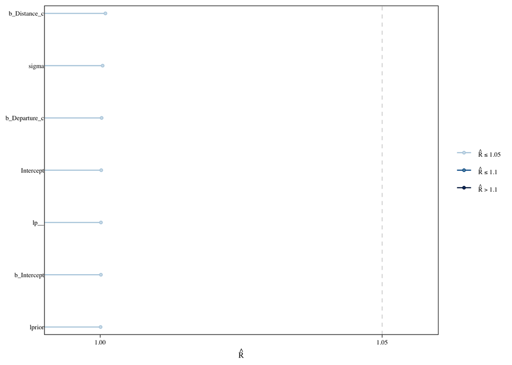

R-hat plot for the parameters in the model

```r
# Note the explicit `brms::`. Several of the packages loaded above export a
# function called `rhat()`, and the one that wins has no method for a brmsfit,
# which throws "no applicable method for 'rhat'". Naming the package settles it.
mcmc_rhat(
  brms::rhat(CommuteTimes_Mod2),
  size = 1) +
  yaxis_text(hjust = 1) # to print parameter names
```

### 2.1.3 Checking auto-correlation

The MCMC-algorithm introduces autocorrelation in the values it samples. Hence, not every sampled value is independent. The **ratio of the effective sample size to the total sample size** gives an idea of the amount of autocorrelation. This ratio should be higher than 0.1 (Gelman et al., 2013). This can be visualized making use of the `mcmc_neff( )` function from the package `bayesplot` and refer to the result of the function `neff_ratio( )`.

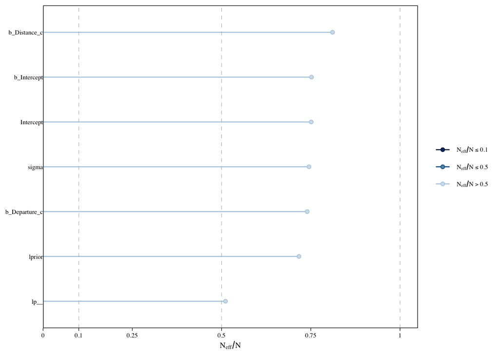

Plot for the ratio’s of effective sample size to the total sample size for each paramater

```r
mcmc_neff(
  brms::neff_ratio(CommuteTimes_Mod2)   # same clash, same fix
  ) +
  yaxis_text(hjust = 1)
```

Another way to get insight into the degree of autocorrelation in the posterior distribution is by plotting it. The plots below show the **level of autocorrelation** for a time lag of 20. Positive values are indicative of a positive correlation between sampled values (and implies that the algorithm stayed in the same region for a while). Therefore, autocorrelation should become 0 as quickly as possible. The plots are generated making use of the `mcmc_acf( )` from `bayesplot`.

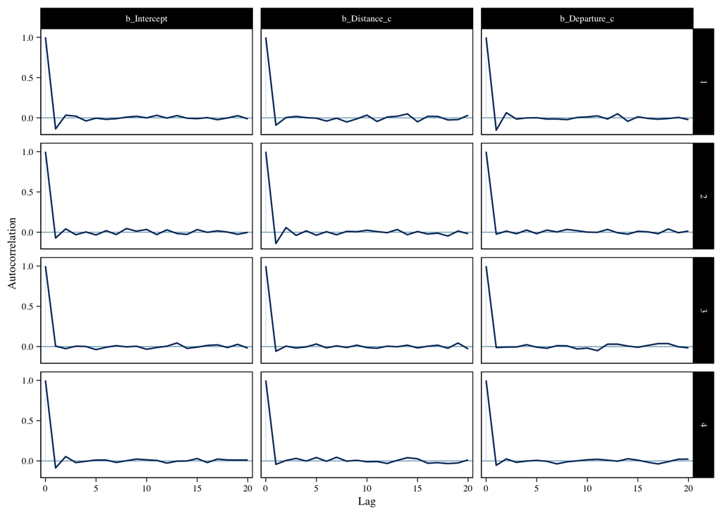

Level of autocorrelation per chain for the intercept and beta’s in the model

```r
mcmc_acf(as.array(CommuteTimes_Mod2), regex = "b")
```

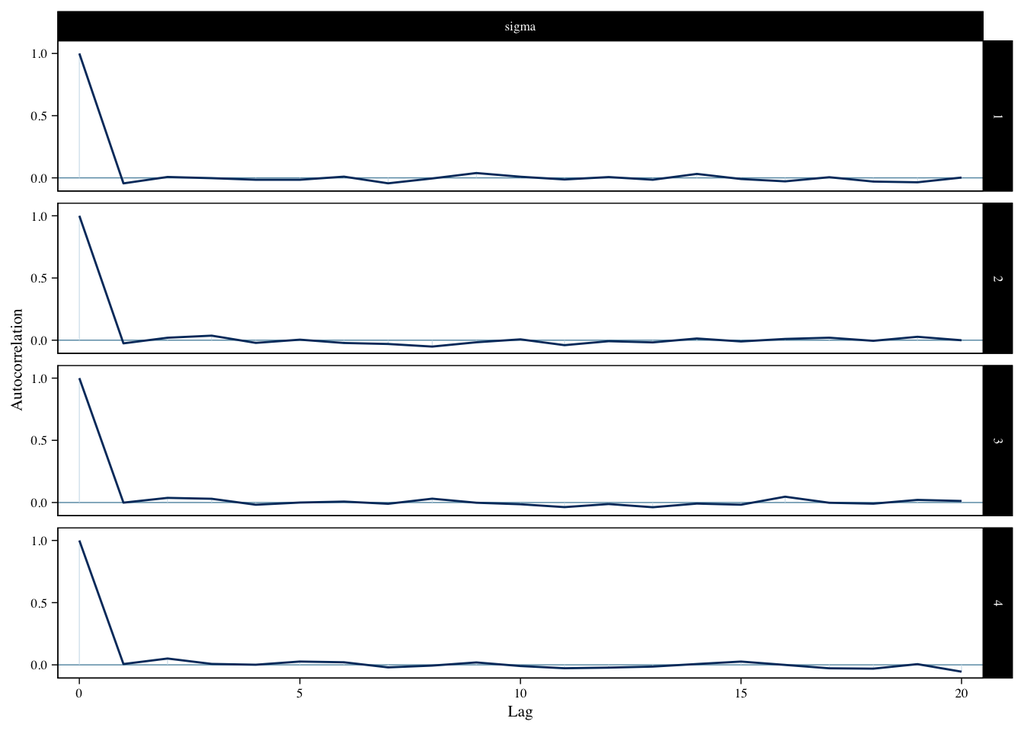

Level of autocorrelation per chain for the residual variance in the model

```r
mcmc_acf(as.array(CommuteTimes_Mod2), regex = "sigma")
```

### 2.1.4 Rank plots

**Rank plots** are an additional way to assess the convergence of MCMC. These plots show histograms of the ranked posterior draws per chain. If the algorithm converged, plots of all chains look similar (Vehtari et al., 2019).

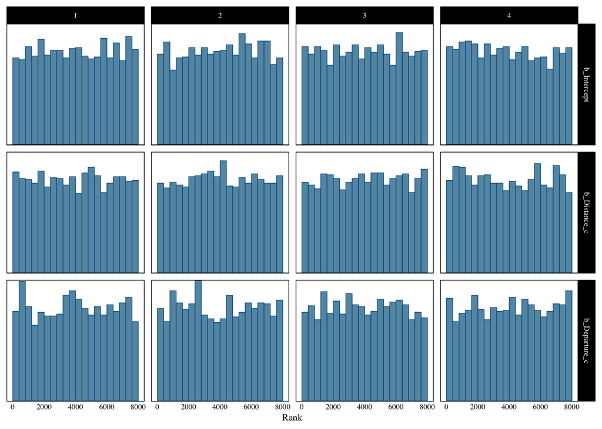

Rank plots for the intercept and beta’s in the model

```r
mcmc_rank_hist(CommuteTimes_Mod2, regex = "b")
```

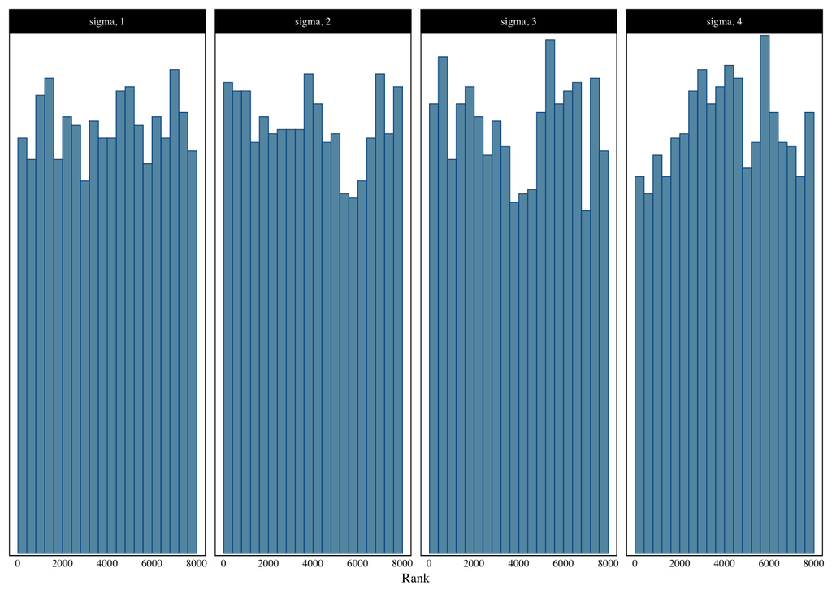

Rank plots for the residual variance in the model

```r
mcmc_rank_hist(CommuteTimes_Mod2, regex = "sigma")
```

## 2.2 Does the posterior distribution histogram have enough information?

Here we make histograms based on the posterior probability distributions for each of the estimated parameters. What we want to see in those histograms is that there is a clear peak and sliding slopes. If the posterior distribution hasn’t got enough information it is not wise to come to conclusions on the probability distribution. This could potentially be overcome with running more iterations.

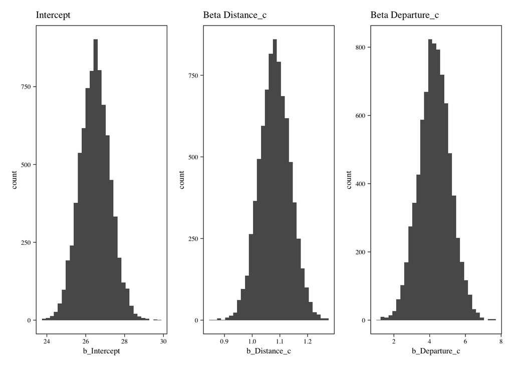

Posterior distribution histograms for the estimates in the final model

```r
posterior_PD <- as_draws_df(CommuteTimes_Mod2)

post_intercept <-
  posterior_PD %>%
  select(b_Intercept) %>%
  ggplot(aes(x = b_Intercept)) +
  geom_histogram() +
  ggtitle("Intercept")

post_distance <-
  posterior_PD %>%
  select(b_Distance_c) %>%
  ggplot(aes(x = b_Distance_c)) +
  geom_histogram() +
  ggtitle("Beta Distance_c")

post_departure <-
  posterior_PD %>%
  select(b_Departure_c) %>%
  ggplot(aes(x = b_Departure_c)) +
  geom_histogram() +
  ggtitle("Beta Departure_c")

post_intercept + post_distance + post_departure +
  plot_layout(ncol = 3)
```

## 2.3 Posterior Predictive Checks

To see how well our model predicts the observed data, we can perform a *posterior predictive check.* This is done by using the `pp_check()` function from the package `brms` (Bürkner 2017).

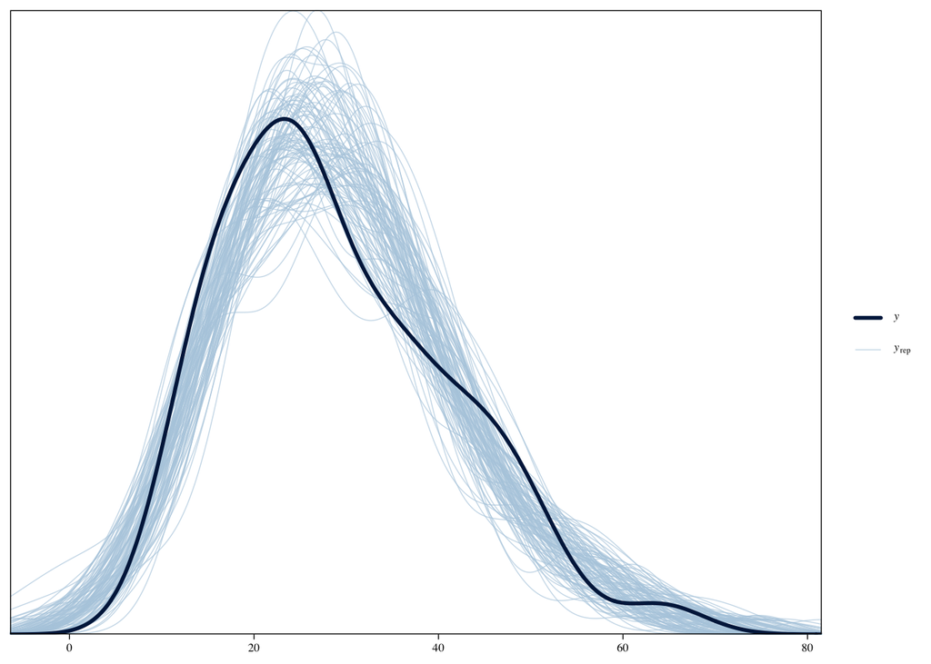

Posterior predictive check for the final model with 100 draws

```r
pp_check(CommuteTimes_Mod2,
         ndraws = 100)
```

From this we can learn that our model predicts the data rather well.

# 3. Understanding the exact influence of the priors

## 3.1 Prior sensitivity analyses

If we have a big dataset, our priors will be overruled by the data. But with smaller datasets a prior can have a significant influence on the results. In either situations, it is important to check how strongly the results are influenced by the priors we used in the model. Therefore, we rely on some functions in the `priorsense` package.

To install the package we used the following:

```r
# install.packages("remotes")
remotes::install_github("n-kall/priorsense")
```

A first quick check is done by using the `powerscale_sensitivity( )` function. This results in a tibble with some information on each of the parameters:

- the column `prior` gives a sensitivity index for the prior (so how sensitive is this parameter to changes in the prior)
- the colum `likelihood` gives a similar sensitivity index for the likelihood
- the column `diagnosis` gives a verbalization of the diagnosis if there is something to consider

The sensitivity indices can be interpreted by making use of a critical value 0.05. If the sensitivity index is higher than 0.05 this means that the parameter is sensitive for changes in the prior and/or likelihood.

```r
ps <- powerscale_sensitivity(CommuteTimes_Mod2)
ps
```

```
Sensitivity based on cjs_dist
Prior selection: all priors
Likelihood selection: all data

      variable prior likelihood diagnosis
   b_Intercept 0.002      0.095         -
  b_Distance_c 0.000      0.090         -
 b_Departure_c 0.000      0.088         -
         sigma 0.003      0.149         -
     Intercept 0.002      0.093         -
```

Of the 5 parameters in that table, 0 exceed 0.05 on the prior index and 5 exceed it on the likelihood index. A low count in the first column is what we are hoping for, because it means the estimates do not lean on the priors. A high count in the second is also what you want, as it implies that our parameter estimates are mainly informed by the data (which translates in the likelihood part of Bayes’ theorem). Both counts are computed from the table above rather than typed in, so they stay correct if you point this template at your own model.

There is also the possibility to visualize this making use of the following code:

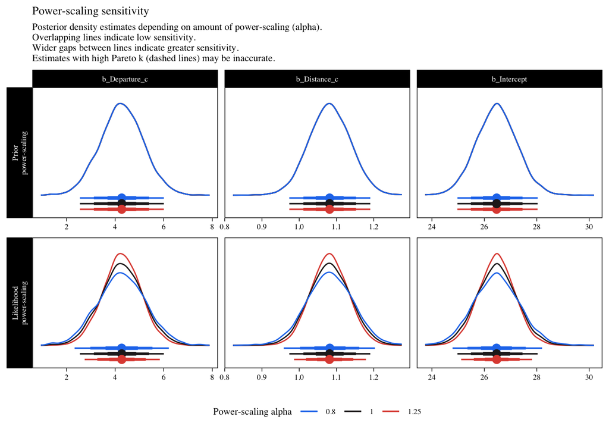

```r
powerscale_plot_dens(
  powerscale_sequence(
    CommuteTimes_Mod2
    ),
  variables = c(
      "b_Intercept",
      "b_Distance_c",
      "b_Departure_c"
    )
  )
```

The resulting graph shows different panels. The panels in the first row show information on the impact of changing the priors on the posterior probability distribution for each of the parameters (= prior sensitivity). Here we see that this shows a single line (all lines are plotted on top of each other), meaning that changing the prior has no impact on the posterior probability distributions for each of these parameters.

The panels in the second row show the information for the likelihood sensitivity. Focussing on the graph for the effect of `Distance_c` we can see that changing the likelihood results in different posterior distributions: if the likelihood gets more weight (gets up-scaled by a positive factor, see more red lines) the posterior gets narrower and more peaked, and vice versa. The same holds for the other two parameters.

Another interesting diagnostic visualization is coming from the `powerscale_plot_quantities( )` function. Here we apply it to the two slope parameters:

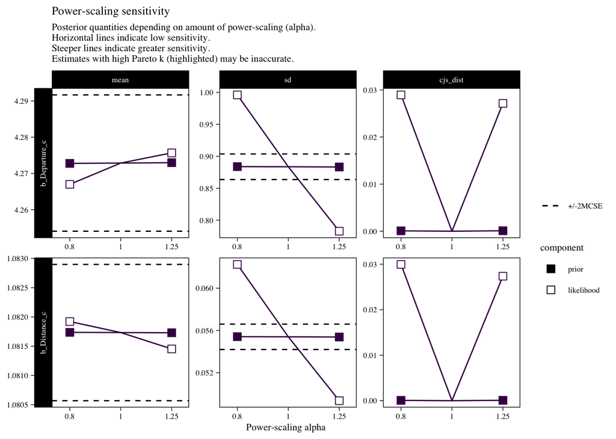

```r
powerscale_plot_quantities(
  powerscale_sequence(
    CommuteTimes_Mod2
    ),
  variables = c(
      "b_Distance_c",
      "b_Departure_c"
      )
  )
```

## References

Bürkner, Paul-Christian. 2017. *Brms: An r Package for Bayesian Multilevel Models Using Stan*. 80. https://doi.org/10.18637/jss.v080.i01.

Depaoli, Rens van de Schoot , Duco Veen , Laurent Smeets , Sonja D. Winter , Sarah. 2020. *A Tutorial on Using the Wambs Checklist to Avoid the Misuse of Bayesian Statistics*. Routledge.

Fernández-i-Marín, Xavier. 2016. *Ggmcmc: Analysis of MCMC Samples and bayesian Inference*. 70. https://doi.org/10.18637/jss.v070.i09.

Gabry, Jonah, and Tristan Mahr. 2022. *Bayesplot: Plotting for Bayesian Models*. https://mc-stan.org/bayesplot/.

Kallioinen, Noa, Topi Paananen, Paul-Christian Bürkner, and Aki Vehtari. 2021. *Detecting and Diagnosing Prior and Likelihood Sensitivity with Power-Scaling*.

Müller, Kirill. 2020. *Here: A Simpler Way to Find Your Files*. https://CRAN.R-project.org/package=here.

Pedersen, Thomas Lin. 2022. *Patchwork: The Composer of Plots*. https://CRAN.R-project.org/package=patchwork.

Schad, Daniel J., Michael Betancourt, and Shravan Vasishth. 2021. “Toward a Principled Bayesian Workflow in Cognitive Science.” *Psychological Methods* 26 (1): 103–26. https://doi.org/10.1037/met0000275.

Vehtari, Aki, Andrew Gelman, Daniel Simpson, Bob Carpenter, and Paul-Christian Bürkner. 2021. “Rank-Normalization, Folding, and Localization: An Improved Rˆ for Assessing Convergence of MCMC (with Discussion).” *Bayesian Analysis* 16 (2). https://doi.org/10.1214/20-ba1221.

Wickham, Hadley, Mara Averick, Jennifer Bryan, et al. 2019. *Welcome to the Tidyverse*. 4: 1686. https://doi.org/10.21105/joss.01686.